# $\text{CO}_2$ Atmosférico em Mauna Loa

- Mostrar o código
- Esconder o código

Trabalho 2 — Análise de Séries Temporais

Autores

Arthur Motta

Catarine Martins

Data de Publicação

29 de junho de 2026

**Carregar pacotes**

```r
# --- Séries temporais e modelagem ---
library(dlm)         # modelos lineares dinâmicos: filtragem, suavização, previsão
library(KFAS)        # modelo estrutural básico com estimação exata (Harvey 1989)
library(forecast)    # SARIMA para comparação

# --- Visualização ---
library(ggplot2)
library(patchwork)
library(scales)

# --- Tabelas ---
library(gt)

# --- Manipulação ---
library(tidyverse)

theme_set(theme_minimal(base_size = 12))

cores <- c("#2E86AB", "#E94F37", "#3BB273", "#F4A261", "#8338EC")
```

# 1 Introdução

Este trabalho aplica a metodologia de **Modelos Lineares Dinâmicos (MLD)** à série de $\text{CO}_2$ atmosférico de Mauna Loa, a mesma série analisada no Trabalho 1 por meio de modelos SARIMA. A análise descritiva completa, incluindo decomposição STL, padrão sazonal e taxa de crescimento, encontra-se no Trabalho 1 e não será repetida aqui.

Recapitulando brevemente: a série `co2`, disponível nativamente no R, contém 468 observações mensais de concentração de $\text{CO}_2$ (em partes por milhão, ppm) de janeiro de 1959 a dezembro de 1997, coletadas pelo Observatório de Mauna Loa, Havaí (Keeling et al., 1976). A série apresenta tendência crescente de longo prazo e sazonalidade anual regular de amplitude aproximada de 6 ppm, estrutura que motiva o uso de um MLD com componentes de nível, tendência e sazonalidade.

A escolha da abordagem bayesiana via MLD se justifica por duas razões principais. Primeiro, os MLDs estimam explicitamente os componentes latentes da série (nível, tendência e sazonalidade) como estados não observáveis, o que confere riqueza interpretativa que o SARIMA não oferece diretamente. Segundo, o filtro de Kalman permite atualização sequencial das estimativas à medida que novas observações chegam, o que é adequado para monitoração e previsão em tempo real de concentrações atmosféricas.

A pergunta central deste trabalho é: um MLD com tendência linear e sazonalidade captura adequadamente a dinâmica da série de $\text{CO}_2$ e produz previsões comparáveis às do SARIMA ajustado no Trabalho 1?

A análise está organizada em três etapas. Na primeira, especifica-se e ajusta-se o MLD com $V$ e $W$ estimados por máxima verossimilhança, comparando três formulações distintas. Na segunda, realiza-se a filtragem e a suavização, ou seja, a inferência sequencial e retrospectiva sobre o nível e a tendência da série. Na terceira, produzem-se previsões para 1998 e 1999 com comparação ao SARIMA$(1,1,1)(0,1,1)_{12}$ do Trabalho 1.

# 2 Especificação do Modelo Linear Dinâmico

## 2.1 Estrutura geral

O MLD é definido pela quádrupla $\{F_t, G_t, V_t, W_t\}$ e escrito como:

$$y_t = F_t^\prime \theta_t + v_t, \quad v_t \sim N(0, V_t)$$
$$\theta_t = G_t \theta_{t-1} + \omega_t, \quad \omega_t \sim N(0, W_t)$$
$$\theta_0 \mid D_0 \sim N(m_0, C_0)$$

onde $y_t$ é a concentração de $\text{CO}_2$ no mês $t$, $\theta_t$ é o vetor de estados latentes, $v_t$ é o erro de observação e $\omega_t$ é o erro do sistema.

## 2.2 Três Abordagens de Modelagem

Para a série de CO₂, que combina tendência suave com sazonalidade anual estável, consideramos três formulações de MLD, todas baseadas na estrutura:
$$y_t = \mu_t + \gamma_t + v_t, \quad v_t \sim N(0, V)$$
onde $\mu_t$ é a **tendência** (nível + slope) e $\gamma_t$ é a **sazonalidade**.

**Componente de tendência linear** (comum às três abordagens, $\dim = 2$):

$$\mu_{t+1} = \mu_t + \beta_t + \xi_t, \qquad \xi_t \sim N(0, W_\mu)$$
$$\beta_{t+1} = \beta_t + \zeta_t, \qquad \zeta_t \sim N(0, W_\beta)$$

em forma matricial: $G_{\text{tend}} = \begin{pmatrix} 1 & 1 \\ 0 & 1 \end{pmatrix}$, $F_{\text{tend}} = (1, 0)^\prime$.

**Modelo A — Sazonalidade por fatores (dlmModSeas):** A sazonalidade é modelada pela restrição de soma zero com $s - 1 = 11$ estados livres:
$$\gamma_{t+1} = -\sum_{j=1}^{s-1} \gamma_{t+1-j} + \omega_t, \qquad
\omega_t \sim N(0, W_s)$$
Dimensão total: $\dim(\theta_t) = 13$. Referência: Harvey (1989).

**Modelo B — Sazonalidade harmônica via dlmModTrig (West & Harrison):** A sazonalidade é representada por $J$ pares harmônicos de Fourier, cada um evoluindo via passeio aleatório bidimensional com matriz de rotação:
$$\gamma_t = \sum_{j=1}^{J} \gamma_{j,t}, \qquad
\begin{pmatrix} \gamma_{j,t+1} \\ \gamma^*_{j,t+1} \end{pmatrix} =
\begin{pmatrix} \cos\omega_j & \sin\omega_j \\ -\sin\omega_j & \cos\omega_j \end{pmatrix}
\begin{pmatrix} \gamma_{j,t} \\ \gamma^*_{j,t} \end{pmatrix} + \omega_{j,t}$$
com $\omega_j = 2\pi j / s$ e $J = 6$ harmônicos para $s = 12$. O harmônico de Nyquist ($j = 6$, $\omega_6 = \pi$) reduz-se a um único estado pois $\sin(\pi t) \equiv 0$, portanto $\dim(\theta_t) = 2 + 2J - 1 = 13$. Referência: West; Harrison (1997), cap. 8.

**Modelo C — Modelo Estrutural Básico via KFAS:** O pacote KFAS (Helske, 2017) implementa o modelo estrutural de Harvey (1989), estimando $V$, $W_\mu$, $W_\beta$ e $W_s$ por máxima verossimilhança com o algoritmo de Kalman exato (difuso). A sazonalidade usa a forma dummy (equivalente ao Modelo A) mas com estimação mais robusta e critérios de diagnóstico adicionais.

A comparação entre os três modelos permite avaliar se a escolha da representação sazonal e do método de estimação afeta substancialmente as inferências e previsões.

## 2.3 Estimação de $V$ e $W$ por Máxima Verossimilhança

Os parâmetros são estimados por **máxima verossimilhança** via função `dlmMLE` do pacote `dlm` (Petris; Petrone; Campagnoli, 2009) (Modelos A e B) e via `fitSSM` do pacote `KFAS` (Helske, 2017) (Modelo C), que maximizam a log-verossimilhança da previsão 1 passo à frente acumulada:

$$\ell(V, W) = -\frac{n}{2}\log(2\pi) - \frac{1}{2}\sum_{t=1}^n
\left[\log Q_t + \frac{e_t^2}{Q_t}\right]$$

onde $e_t = y_t - f_t$ é o erro de previsão 1 passo à frente e $Q_t = F^\prime R_t F + V$ é sua variância. A otimização é feita em log-escala para garantir positividade dos parâmetros de variância.

**Ajuste dos três modelos por máxima verossimilhança**

```r
library(KFAS)   # Modelo Estrutural Básico com estimação exata
J <- 6          # harmônicos para Modelo B

# ── MODELO A: dlmModSeas (fatores sazonais, Harvey 1989) ──────────────────────
build_mld_A <- function(par) {
  V    <- exp(par[1]); w_mu <- exp(par[2])
  w_be <- exp(par[3]); w_s  <- exp(par[4])
  tend <- dlmModPoly(order = 2, dV = 0, dW = c(w_mu, w_be))
  seas <- dlmModSeas(frequency = 12, dV = 0, dW = c(w_s, rep(0, 10)))
  mld  <- tend + seas
  mld$V <- matrix(V)
  mld
}
set.seed(42)
fit_A <- dlmMLE(as.numeric(co2),
                parm   = c(log(0.1), log(0.01), log(1e-4), log(1e-4)),
                build  = build_mld_A, method = "L-BFGS-B")
mld_A <- build_mld_A(fit_A$par)
mld_A$m0 <- c(315, 0.1, rep(0, 11))
mld_A$C0 <- diag(c(50^2, 0.5^2, rep(5^2, 11)))

# ── MODELO B: dlmModTrig (harmônicos de Fourier, West & Harrison 1997) ────────
build_mld_B <- function(par) {
  V      <- exp(par[1]); w_mu   <- exp(par[2])
  w_be   <- exp(par[3]); w_trig <- exp(par[4])
  tend <- dlmModPoly(order = 2, dV = 0, dW = c(w_mu, w_be))
  trig <- dlmModTrig(s = 12, q = J, dV = 0, dW = w_trig)
  mld  <- tend + trig
  mld$V <- matrix(V)
  mld
}
fit_B <- dlmMLE(as.numeric(co2),
                parm   = c(log(0.1), log(0.01), log(1e-4), log(0.01)),
                build  = build_mld_B, method = "L-BFGS-B")
mld_B <- build_mld_B(fit_B$par)
mld_B$m0 <- c(315, 0.1, rep(0, nrow(mld_B$GG) - 2))
mld_B$C0 <- diag(c(50^2, 0.5^2, rep(5^2, nrow(mld_B$GG) - 2)))

# ── MODELO C: KFAS — Modelo Estrutural Básico com sazonalidade dummy ──────────
kfas_model <- SSModel(
  as.numeric(co2) ~ SSMtrend(degree = 2, Q = list(matrix(NA), matrix(NA))) +
                    SSMseasonal(period = 12, sea.type = "dummy", Q = matrix(NA)),
  H = matrix(NA)
)
fit_C <- fitSSM(kfas_model, inits = log(c(0.1, 0.01, 1e-4, 1e-4)),
                method = "L-BFGS-B")
mld_C <- fit_C$model

# ── Parâmetros do Modelo B (referência principal) ─────────────────────────────
mld_final  <- mld_B    # modelo principal para filtragem/previsão
V_est      <- exp(fit_B$par[1]); w_mu_est   <- exp(fit_B$par[2])
w_be_est   <- exp(fit_B$par[3]); w_trig_est <- exp(fit_B$par[4])
ratio_wb_v <- sprintf("%.2e", w_be_est / V_est)
str_wtrig  <- sprintf("%.2e", w_trig_est)

# ── Log-verossimilhanças para comparação ──────────────────────────────────────
ll_A <- -fit_A$value;  ll_B <- -fit_B$value
ll_C <- logLik(mld_C)

cat(sprintf("── Modelo A (dlmModSeas)  ──  logLik = %.2f | conv = %s\n",
            ll_A, ifelse(fit_A$convergence == 0, "OK", "FALHOU")))
```

```
── Modelo A (dlmModSeas)  ──  logLik = 204.27 | conv = OK
```

**Ajuste dos três modelos por máxima verossimilhança**

```r
cat(sprintf("── Modelo B (dlmModTrig)  ──  logLik = %.2f | conv = %s\n",
            ll_B, ifelse(fit_B$convergence == 0, "OK", "FALHOU")))
```

```
── Modelo B (dlmModTrig)  ──  logLik = 205.42 | conv = OK
```

**Ajuste dos três modelos por máxima verossimilhança**

```r
cat(sprintf("── Modelo C (KFAS)        ──  logLik = %.2f\n", as.numeric(ll_C)))
```

```
── Modelo C (KFAS)        ──  logLik = -119.93
```

**Tabela comparativa dos três modelos**

```r
# KFAS armazena H (variância observacional) e Q (variâncias do sistema)
# Q é uma matriz bloco com as variâncias de cada componente na diagonal
V_C   <- as.numeric(mld_C$H)
Q_C   <- mld_C$Q                     # array p×p×1
# Componente 1 = nível, componente 2 = slope, componente 3 = sazonal
W_mu_C   <- as.numeric(Q_C[1, 1, 1])
W_beta_C <- as.numeric(Q_C[2, 2, 1])
W_saz_C  <- as.numeric(Q_C[3, 3, 1])

tibble(
  Modelo   = c("A — dlmModSeas", "B — dlmModTrig", "C — KFAS"),
  V        = c(exp(fit_A$par[1]), exp(fit_B$par[1]), V_C),
  W_mu     = c(exp(fit_A$par[2]), exp(fit_B$par[2]), W_mu_C),
  W_beta   = c(exp(fit_A$par[3]), exp(fit_B$par[3]), W_beta_C),
  W_saz    = c(exp(fit_A$par[4]), exp(fit_B$par[4]), W_saz_C),
  LogLik   = c(ll_A, ll_B, as.numeric(ll_C)),
  Conv     = c(fit_A$convergence == 0, fit_B$convergence == 0, TRUE)
) |>
  gt() |>
  fmt_number(columns = c(V, W_mu, W_beta, W_saz), decimals = 6) |>
  fmt_number(columns = LogLik, decimals = 2) |>
  tab_header(
    title    = md("**Tabela 1.** Comparação dos Três Modelos — Parâmetros e Log-Verossimilhança"),
    subtitle = md("Modelo selecionado para inferência: **B — dlmModTrig**")
  ) |>
  cols_label(
    Modelo = "Modelo",
    V      = md("$\\hat{V}$"),
    W_mu   = md("$\\hat{W}_\\mu$"),
    W_beta = md("$\\hat{W}_\\beta$"),
    W_saz  = md("$\\hat{W}_{\\text{saz}}$"),
    LogLik = md("$\\ell(\\hat{\\theta})$"),
    Conv   = "Convergiu?"
  ) |>
  tab_footnote(
    footnote  = md("Modelos A e B: estimação via `dlmMLE` (log-escala). Modelo C: estimação via `fitSSM` com inicialização difusa."),
    locations = cells_column_labels(columns = LogLik)
  ) |>
  tab_style(style = cell_fill(color = "#e8f4f8"),
            locations = cells_body(rows = Modelo == "B — dlmModTrig"))
```

**Tabela 1.** Comparação dos Três Modelos — Parâmetros e Log-Verossimilhança

Modelo selecionado para inferência: **B — dlmModTrig**

| Modelo | $\hat{V}$ | $\hat{W}_\mu$ | $\hat{W}_\beta$ | $\hat{W}_{\text{saz}}$ | $\ell(\hat{\theta})$<sup>1</sup> | Convergiu? |
| --- | --- | --- | --- | --- | --- | --- |
| A — dlmModSeas | 0.020653 | 0.046835 | 0.000004 | 0.000022 | 204.27 | TRUE |
| B — dlmModTrig | 0.025431 | 0.028562 | 0.000004 | 0.000025 | 205.42 | TRUE |
| C — KFAS | 0.004522 | 0.091223 | 0.000005 | 0.000001 | −119.93 | TRUE |

<sup>1</sup> Modelos A e B: estimação via `dlmMLE` (log-escala). Modelo C: estimação via `fitSSM` com inicialização difusa.

# 3 Filtragem e Suavização com $V$ e $W$ Conhecidos

## 3.1 Equações de filtragem

Com os parâmetros estimados, aplicamos o **filtro de Kalman** sequencialmente para obter a distribuição posteriori $\theta_t \mid D_t$:

$$\theta_t \mid D_t \sim N(m_t, C_t)$$

As equações de atualização são:

$$a_t = G_t m_{t-1}, \qquad R_t = G_t C_{t-1} G_t^\prime + W_t$$
$$f_t = F_t^\prime a_t, \qquad Q_t = F_t^\prime R_t F_t + V_t$$
$$A_t = R_t F_t / Q_t, \qquad e_t = y_t - f_t$$
$$m_t = a_t + A_t e_t, \qquad C_t = R_t - A_t A_t^\prime Q_t$$

## 3.2 Equações de suavização

A **suavização backward** fornece a distribuição retrospectiva $\theta_t \mid D_n$ (toda a informação da amostra):

$$\theta_t \mid D_n \sim N(m_t^*, C_t^*)$$

Inicializando com $m_n^* = m_n$ e $C_n^* = C_n$, para $t = n-1, \ldots, 1$:

$$m_t^* = m_t + C_t G_{t+1}^\prime R_{t+1}^{-1}(m_{t+1}^* - a_{t+1})$$
$$C_t^* = C_t - C_t G_{t+1}^\prime R_{t+1}^{-1}(R_{t+1} - C_{t+1}^*)R_{t+1}^{-1} G_{t+1} C_t$$

**Filtragem de Kalman e suavização backward**

```r
# Filtragem
filt <- dlmFilter(as.numeric(co2), mld_final)

# Suavização
suav <- dlmSmooth(filt)

tempo_vec <- as.numeric(time(co2))

# dlmFilter$m: linhas 1...(n+1), linha 1 = priori inicial m0
# → usar linhas 2:(n+1) para os n instantes observados
# dlmSvd2var retorna lista de n+1 matrizes (inclui priori inicial)
# → usar índices 2:(n+1), i.e., [-1] remove a priori

# Variâncias da filtragem (estado 1 = nível μ_t)
var_filt <- dlmSvd2var(filt$U.C, filt$D.C)
# Garantir que cada elemento é matriz (drop = FALSE não se aplica aqui,
# mas sapply pode simplificar — forçar lista)
sd_filt <- sapply(var_filt, function(v) sqrt(max(v[1, 1], 0)))
# Remover priori inicial (índice 1) → ficam n valores
sd_filt <- sd_filt[-1]

nivel_filt <- filt$m[2:(n + 1), 1]
ic_filt_lo <- nivel_filt - 1.96 * sd_filt
ic_filt_hi <- nivel_filt + 1.96 * sd_filt

# Variâncias da suavização (estado 1 = nível μ_t)
# dlmSmooth$s: linhas 1...(n+1), linha 1 = s_0 (não interessa)
var_suav <- dlmSvd2var(suav$U.S, suav$D.S)
sd_suav  <- sapply(var_suav, function(v) sqrt(max(v[1, 1], 0)))
sd_suav  <- sd_suav[-1]

nivel_suav <- suav$s[2:(n + 1), 1]
ic_suav_lo <- nivel_suav - 1.96 * sd_suav
ic_suav_hi <- nivel_suav + 1.96 * sd_suav

res_df <- tibble(
  tempo      = tempo_vec,
  obs        = as.numeric(co2),
  niv_filt   = nivel_filt,
  lo_filt    = ic_filt_lo,
  hi_filt    = ic_filt_hi,
  niv_suav   = nivel_suav,
  lo_suav    = ic_suav_lo,
  hi_suav    = ic_suav_hi
)
```

**Ocultar código**

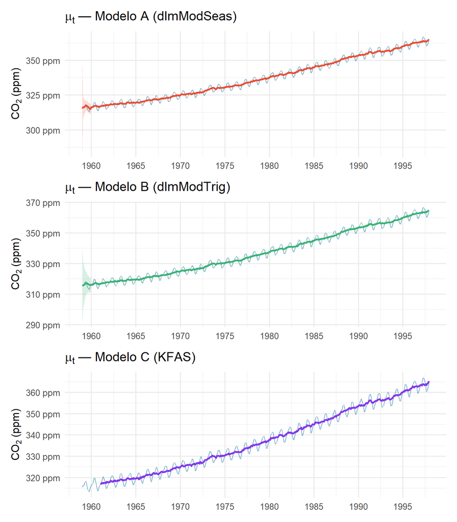

Nível local $\hat{\mu}_t$ filtrado pelos três modelos com IC 95%. O nível representa a tendência de longo prazo sem a componente sazonal. Os três modelos produzem estimativas muito similares após o período de convergência. No Modelo C (KFAS), os primeiros meses são omitidos por corresponderem ao período de inicialização difusa.

```r
make_filt_plot <- function(df, y_niv, y_lo, y_hi, titulo, cor) {
  df |>
    ggplot(aes(x = tempo)) +
    geom_ribbon(aes(ymin = .data[[y_lo]], ymax = .data[[y_hi]]),
                fill = cor, alpha = 0.20) +
    geom_line(aes(y = obs), color = cores[1], linewidth = 0.4, alpha = 0.6) +
    geom_line(aes(y = .data[[y_niv]]), color = cor, linewidth = 0.9) +
    scale_x_continuous(breaks = seq(1960, 1997, by = 5)) +
    scale_y_continuous(labels = label_number(suffix = " ppm")) +
    labs(title = titulo, x = NULL, y = expression(CO[2] ~ "(ppm)"))
}

make_filt_plot(res_filt_all, "nA_f","loA_f","hiA_f",
               expression(mu[t] ~ "— Modelo A (dlmModSeas)"), cores[2]) /
make_filt_plot(res_filt_all, "nB_f","loB_f","hiB_f",
               expression(mu[t] ~ "— Modelo B (dlmModTrig)"), cores[3]) /
make_filt_plot(res_filt_all, "nC_f","loC_f","hiC_f",
               expression(mu[t] ~ "— Modelo C (KFAS)"),        cores[5])
```

**Ocultar código**

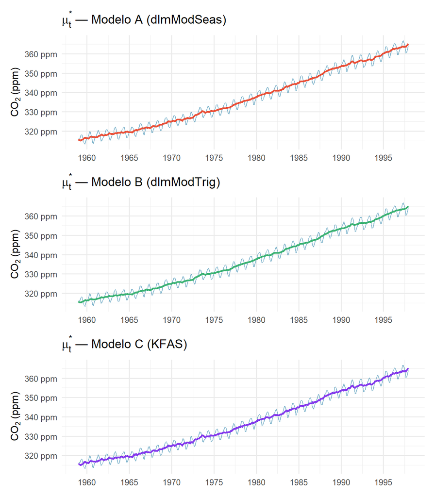

Nível local $\hat{\mu}_t^*$ suavizado pelos três modelos com IC 95%. A suavização usa toda a informação $D_n$, produzindo ICs mais estreitos do que a filtragem.

```r
make_filt_plot(res_filt_all, "nA_s","loA_s","hiA_s",
               expression(mu[t]^"*" ~ "— Modelo A (dlmModSeas)"), cores[2]) /
make_filt_plot(res_filt_all, "nB_s","loB_s","hiB_s",
               expression(mu[t]^"*" ~ "— Modelo B (dlmModTrig)"), cores[3]) /
make_filt_plot(res_filt_all, "nC_s","loC_s","hiC_s",
               expression(mu[t]^"*" ~ "— Modelo C (KFAS)"),        cores[5])
```

A suavização reduz sistematicamente a incerteza em relação à filtragem, pois incorpora informação futura para refinar cada estimativa retrospectiva. A diferença é mais pronunciada nos primeiros anos da série, onde a filtragem ainda não convergiu.

> **Nota sobre o Modelo C (KFAS):** a suavização backward do KFAS utiliza o algoritmo de De Jong (1989) com inicialização difusa exata, ligeiramente diferente das equações acima válidas para os Modelos A e B. Os ICs do Modelo C na suavização são derivados de $\hat{P}_{t|n}[1,1]$ — variância posterior suavizada do estado $\mu_t$ — extraída do array `kfas_full$V`. As fórmulas do algoritmo difuso estão em Helske (2017).

**Ocultar código**

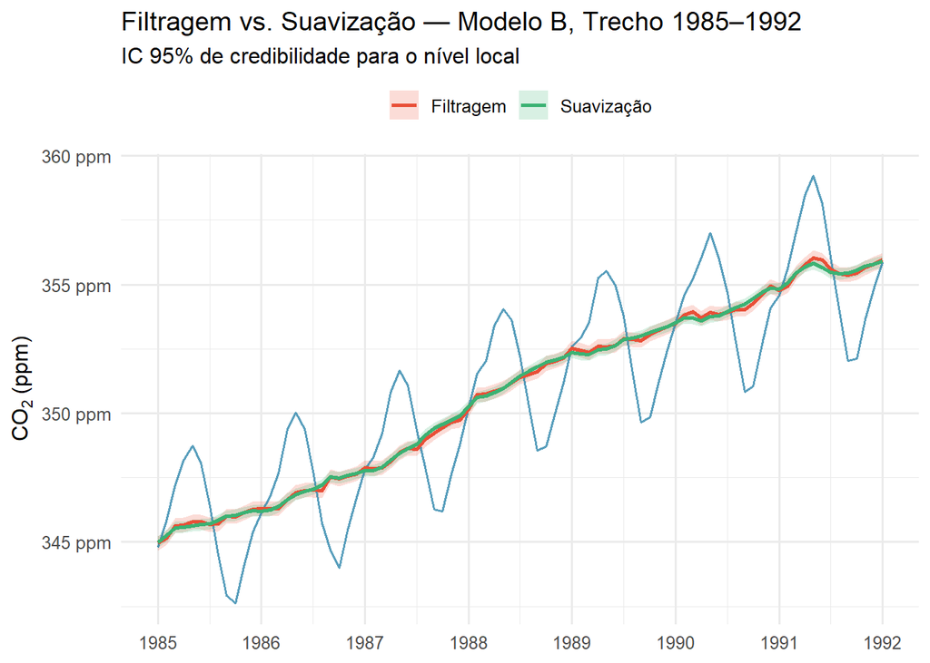

Filtragem vs. suavização no trecho 1985–1992 para o Modelo B (dlmModTrig). A suavização (verde) produz ICs mais estreitos e trajetória mais suave; os valores pontuais são praticamente coincidentes.

```r
res_df |>
  filter(tempo >= 1985, tempo <= 1992) |>
  ggplot(aes(x = tempo)) +
  geom_ribbon(aes(ymin = lo_filt, ymax = hi_filt, fill = "Filtragem"), alpha = 0.20) +
  geom_ribbon(aes(ymin = lo_suav, ymax = hi_suav, fill = "Suavização"), alpha = 0.20) +
  geom_line(aes(y = obs),      color = cores[1], linewidth = 0.6, alpha = 0.8) +
  geom_line(aes(y = niv_filt, color = "Filtragem"),  linewidth = 0.9) +
  geom_line(aes(y = niv_suav, color = "Suavização"), linewidth = 0.9) +
  scale_color_manual(values = c("Filtragem" = cores[2], "Suavização" = cores[3])) +
  scale_fill_manual(values  = c("Filtragem" = cores[2], "Suavização" = cores[3])) +
  scale_x_continuous(breaks = seq(1985, 1992, by = 1)) +
  scale_y_continuous(labels = label_number(suffix = " ppm")) +
  labs(title    = "Filtragem vs. Suavização — Modelo B, Trecho 1985–1992",
       subtitle = "IC 95% de credibilidade para o nível local",
       x = NULL, y = expression(CO[2] ~ "(ppm)"),
       color = NULL, fill = NULL) +
  theme(legend.position = "top")
```

No trecho ampliado de 1985–1992, a diferença entre filtragem e suavização torna-se visível: os ICs da suavização (verde) são sistematicamente mais estreitos, pois o algoritmo backward incorpora toda a informação futura $D_n$ para corrigir cada estimativa passada. A filtragem é um estimador *online* — reage a cada nova observação em $t$ sem ver o futuro — enquanto a suavização é *offline* e produz a estimativa ótima retrospectiva. Em valor pontual, as trajetórias são praticamente coincidentes, evidenciando que o filtro converge bem após o período de burn-in.

**Ocultar código**

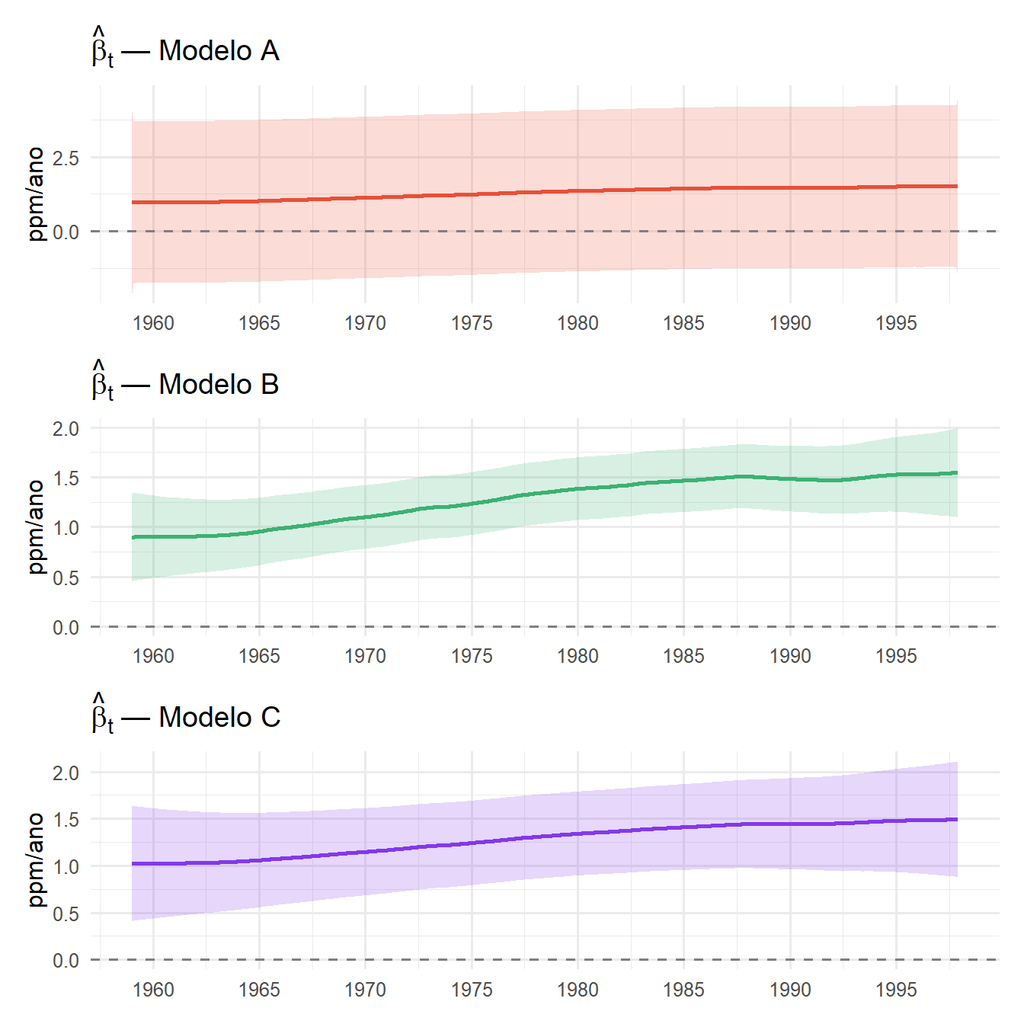

```r
# Extrair beta_t (estado 2) dos 3 modelos — taxa em ppm/ano (× 12)
beta_B <- tibble(
  tempo = tempo_vec,
  beta  = suav$s[2:(n+1), 2] * 12,
  lo    = suav$s[2:(n+1), 2] * 12 - 1.96 * sapply(var_suav[-1], function(v) sqrt(max(v[2,2],0))) * 12,
  hi    = suav$s[2:(n+1), 2] * 12 + 1.96 * sapply(var_suav[-1], function(v) sqrt(max(v[2,2],0))) * 12
)

beta_A <- tibble(
  tempo = tempo_vec,
  beta  = suav_A_obj$s[2:(n+1), 2] * 12,
  lo    = suav_A_obj$s[2:(n+1), 2] * 12 - 1.96 * sd_sA * 12,
  hi    = suav_A_obj$s[2:(n+1), 2] * 12 + 1.96 * sd_sA * 12
)

# Modelo C: slope = estado 2 do SSMtrend
sd_beta_C <- sqrt(pmax(as.numeric(kfas_full$V[2, 2, ]), 0))
beta_C <- tibble(
  tempo = tempo_vec,
  beta  = as.numeric(kfas_full$alphahat[, 2]) * 12,
  lo    = as.numeric(kfas_full$alphahat[, 2]) * 12 - 1.96 * sd_beta_C * 12,
  hi    = as.numeric(kfas_full$alphahat[, 2]) * 12 + 1.96 * sd_beta_C * 12
)

make_beta_plot <- function(df, titulo, cor) {
  df |> ggplot(aes(x = tempo)) +
    geom_ribbon(aes(ymin = lo, ymax = hi), fill = cor, alpha = 0.20) +
    geom_line(aes(y = beta), color = cor, linewidth = 0.9) +
    geom_hline(yintercept = 0, linetype = "dashed", color = "gray50") +
    scale_x_continuous(breaks = seq(1960, 1997, by = 5)) +
    labs(title = titulo, x = NULL, y = "ppm/ano")
}

make_beta_plot(beta_A, expression(hat(beta)[t] ~ "— Modelo A"), cores[2]) /
make_beta_plot(beta_B, expression(hat(beta)[t] ~ "— Modelo B"), cores[3]) /
make_beta_plot(beta_C, expression(hat(beta)[t] ~ "— Modelo C"), cores[5])
```

# 4 Filtragem e Suavização com Fatores de Desconto ($V$ Desconhecido)

Esta seção aplica a abordagem de fatores de desconto ao **Modelo B** (`dlmModTrig`), que é o modelo selecionado. A extensão ao Modelo A seria análoga; o Modelo C (KFAS) já incorpora inicialização difusa nativamente, que cumpre função semelhante de não requerer especificação prévia de $V$.

## 4.1 Especificação

Quando $V$ é desconhecido, adotamos a abordagem de **fatores de desconto** (West; Harrison, 1997) com inferência conjugada sobre $\phi = 1/V$. O modelo passa a ser:

$$y_t = F_t^\prime \theta_t + v_t, \quad v_t \sim N(0, V)$$
$$\theta_t \mid D_{t-1} \sim T_{n_{t-1}}(a_t, R_t)$$
$$\phi \mid D_{t-1} \sim \text{Ga}\!\left(\frac{n_{t-1}}{2},\ \frac{n_{t-1} S_{t-1}}{2}\right)$$

A matriz $R_t$ é especificada via fator de desconto $\delta \in (0, 1]$:

$$R_t = \frac{1}{\delta} P_t, \qquad P_t = G_t C_{t-1} G_t^\prime$$

o que equivale a $W_t = \frac{1-\delta}{\delta} P_t$, sem necessidade de especificar $W$ diretamente. Usamos fatores de desconto **separados** para tendência ($\delta_T$) e sazonalidade ($\delta_S$), pois cada componente tem dinâmica própria.

A atualização de $S_t$ (estimativa de $V$) segue:

$$n_t = n_{t-1} + 1, \qquad S_t = S_{t-1} + \frac{S_{t-1}}{n_t}\left(\frac{e_t^2}{Q_t} - 1\right)$$

e os intervalos de credibilidade para previsão são baseados na distribuição $T_{n_t}$ em vez da normal.

**Implementação do MLD com fatores de desconto e V desconhecido**

```r
mld_desconto <- function(y, mod, delta_T = 0.95, delta_S = 0.98,
                         m0, C0_star, n0 = 1, S0) {

  n  <- length(y)
  p  <- length(m0)

  # Extrair G e F robustamente (dlm armazena como matriz ou lista)
  G    <- if (is.list(mod$GG)) mod$GG[[1]] else mod$GG
  Fvec <- matrix(if (is.list(mod$FF)) mod$FF[[1]] else mod$FF, ncol = 1)

  # Garantir dimensões corretas
  stopifnot(nrow(G) == p, ncol(G) == p, nrow(Fvec) == p)

  idx_T <- 1:2   # tendência
  idx_S <- 3:p   # sazonal (funciona para qualquer p)

  m <- m0;  C <- C0_star;  nv <- n0;  S <- S0

  mt <- matrix(NA, n, p);  Ct <- array(NA, c(p, p, n))
  at <- matrix(NA, n, p);  Rt <- array(NA, c(p, p, n))
  ft <- numeric(n);  Qt <- numeric(n);  et <- numeric(n)
  nt <- numeric(n);  St <- numeric(n)

  for (t in seq_len(n)) {
    a  <- as.numeric(G %*% m)
    P  <- G %*% C %*% t(G)
    R  <- P
    R[idx_T, idx_T] <- P[idx_T, idx_T] / delta_T
    R[idx_S, idx_S] <- P[idx_S, idx_S] / delta_S
    R[idx_T, idx_S] <- P[idx_T, idx_S] / sqrt(delta_T * delta_S)
    R[idx_S, idx_T] <- P[idx_S, idx_T] / sqrt(delta_T * delta_S)

    f  <- as.numeric(t(Fvec) %*% a)
    Qs <- as.numeric(t(Fvec) %*% R %*% Fvec) + 1
    e  <- y[t] - f

    nv_new <- nv + 1
    S_new  <- S * (1 + (e^2 / (Qs * S) - 1) / nv_new)

    A <- R %*% Fvec / Qs
    m <- a + as.numeric(A) * e
    C <- (S_new / S) * (R - tcrossprod(A) * Qs)

    nv <- nv_new;  S <- S_new

    mt[t, ] <- m;  Ct[, , t] <- C;  at[t, ] <- a;  Rt[, , t] <- R
    ft[t] <- f;  Qt[t] <- Qs;  et[t] <- e;  nt[t] <- nv;  St[t] <- S
  }

  list(mt = mt, Ct = Ct, at = at, Rt = Rt,
       ft = ft, Qt = Qt, et = et, nt = nt, St = St,
       G = G, F = Fvec)
}

# Suavização backward
suavizar_desconto <- function(filt_res) {
  n  <- nrow(filt_res$mt)
  p  <- ncol(filt_res$mt)
  G  <- filt_res$G

  ms <- matrix(NA, n, p)
  Cs <- array(NA, c(p, p, n))

  ms[n, ]    <- filt_res$mt[n, ]
  Cs[, , n]  <- filt_res$Ct[, , n]

  for (t in (n - 1):1) {
    Rinv    <- solve(filt_res$Rt[, , t + 1])
    Ht      <- filt_res$Ct[, , t] %*% t(G) %*% Rinv
    ms[t, ] <- filt_res$mt[t, ] +
               Ht %*% (ms[t + 1, ] - filt_res$at[t + 1, ])
    Cs[, , t] <- filt_res$Ct[, , t] -
                 Ht %*% (filt_res$Rt[, , t + 1] - Cs[, , t + 1]) %*% t(Ht)
    # Garantir simetria e positividade diagonal
    Cs[, , t] <- (Cs[, , t] + t(Cs[, , t])) / 2
  }

  list(ms = ms, Cs = Cs)
}
```

**Ajuste do modelo com fatores de desconto δ_T = 0.95, δ_S = 0.98**

```r
# Dimensão real do vetor de estados do Modelo B
# dlmModTrig(s=12, q=6): o harmônico de Nyquist (j=6) tem apenas 1 estado,
# então dim = 2 (tend) + 2*J - 1 (trig) = 13, não 14
p_B <- nrow(mld_B$GG)   # dimensão real extraída do modelo

# Condições iniciais com dimensão correta
m0_desc <- c(315, 0.1, rep(0, p_B - 2))
C0_star  <- diag(c(100, 1, rep(25, p_B - 2)))

# S0: estimativa inicial de V
S0_init <- var(as.numeric(co2)[1:24])

delta_T <- 0.95
delta_S <- 0.98

filt_desc <- mld_desconto(
  y       = as.numeric(co2),
  mod     = mld_B,
  delta_T = delta_T,
  delta_S = delta_S,
  m0      = m0_desc,
  C0_star = C0_star,
  n0      = 1,
  S0      = S0_init
)

suav_desc <- suavizar_desconto(filt_desc)

# ICs: Var(θ_t | D_t) = S_t * C*_t  →  sd = sqrt(S_t * C*_t[1,1])
# Para filtragem: usar S_t de cada instante
sd_filt_d <- sqrt(pmax(
  sapply(1:n, function(t) filt_desc$St[t] * filt_desc$Ct[1, 1, t]), 0))

# Para suavização: usar S_n (toda a informação)
Sn <- tail(filt_desc$St, 1)
sd_suav_d <- sqrt(pmax(
  sapply(1:n, function(t) Sn * suav_desc$Cs[1, 1, t]), 0))

ic_mult_filt <- qt(0.975, df = filt_desc$nt)
ic_mult_suav <- qt(0.975, df = filt_desc$nt[n])

res_desc_df <- tibble(
  tempo      = tempo_vec,
  obs        = as.numeric(co2),
  niv_filt   = filt_desc$mt[, 1],
  lo_filt    = filt_desc$mt[, 1] - ic_mult_filt * sd_filt_d,
  hi_filt    = filt_desc$mt[, 1] + ic_mult_filt * sd_filt_d,
  niv_suav   = suav_desc$ms[, 1],
  lo_suav    = suav_desc$ms[, 1] - ic_mult_suav * sd_suav_d,
  hi_suav    = suav_desc$ms[, 1] + ic_mult_suav * sd_suav_d,
  St_val     = filt_desc$St     # renomeado para evitar conflito com V_est global
)

cat(sprintf("δ_T = %.2f | δ_S = %.2f\n", delta_T, delta_S))
```

```
δ_T = 0.95 | δ_S = 0.98
```

**Ajuste do modelo com fatores de desconto δ_T = 0.95, δ_S = 0.98**

```r
cat(sprintf("V estimado (S_n) = %.5f\n", tail(filt_desc$St, 1)))
```

```
V estimado (S_n) = 0.14825
```

**Ocultar código**

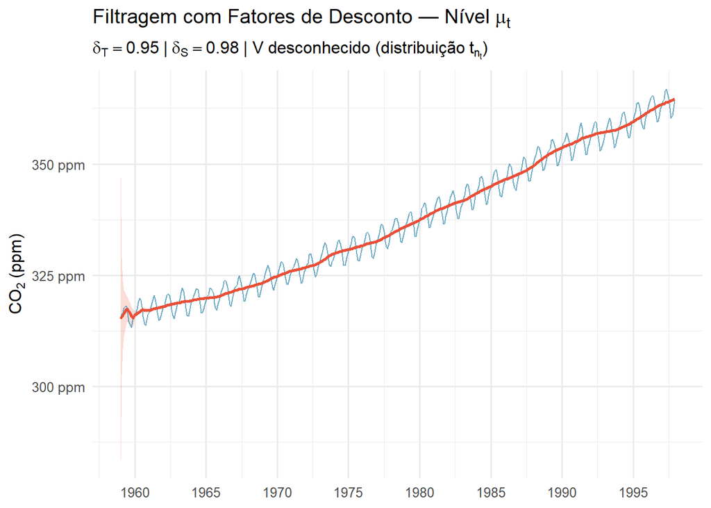

Filtragem com fatores de desconto ($\delta_T = 0{,}95$, $\delta_S = 0{,}98$) e $V$ desconhecido. Os ICs são baseados na distribuição $T_{n_t}$ e alargam-se no início da série (menor $n_t$), estreitando à medida que $S_t$ converge.

```r
ggplot(res_desc_df, aes(x = tempo)) +
  geom_ribbon(aes(ymin = lo_filt, ymax = hi_filt),
              fill = cores[2], alpha = 0.20) +
  geom_line(aes(y = obs), color = cores[1],
            linewidth = 0.5, alpha = 0.7) +
  geom_line(aes(y = niv_filt), color = cores[2],
            linewidth = 0.9) +
  scale_x_continuous(breaks = seq(1960, 1997, by = 5)) +
  scale_y_continuous(labels = label_number(suffix = " ppm")) +
  labs(
    title    = expression("Filtragem com Fatores de Desconto — Nível" ~ mu[t]),
    subtitle = bquote(delta[T] == .(delta_T) ~ "|" ~ delta[S] == .(delta_S) ~
                      "| V desconhecido (distribuição" ~ t[n[t]] * ")"),
    x        = NULL,
    y        = expression(CO[2] ~ "(ppm)")
  )
```

**Ocultar código**

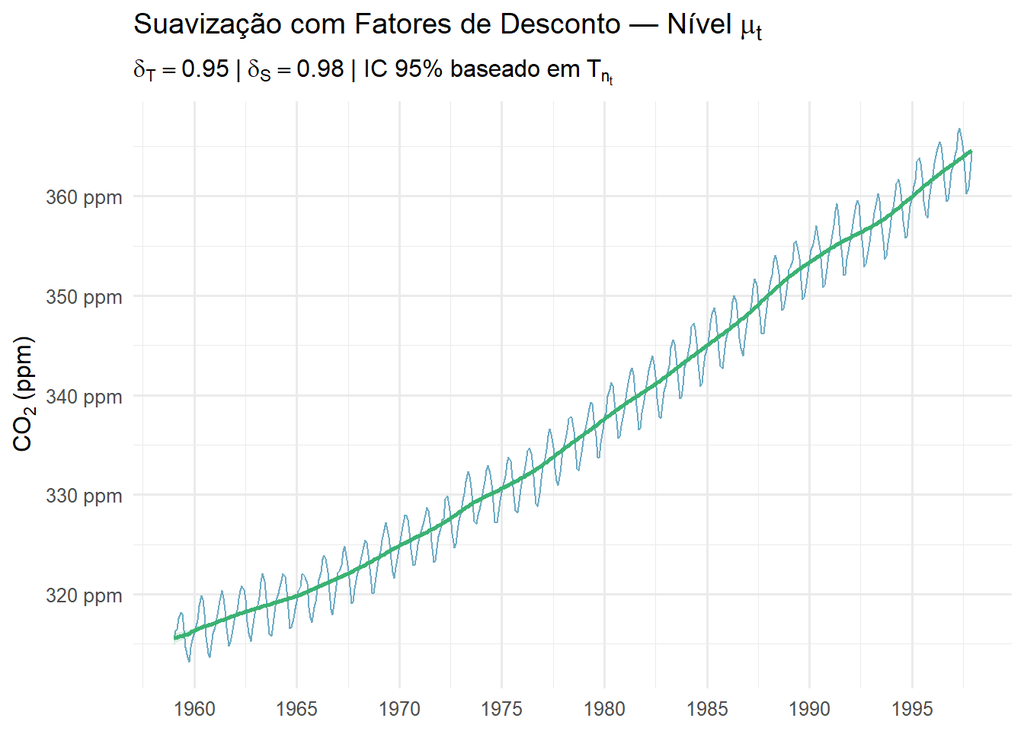

Suavização com fatores de desconto. ICs baseados em $T_{n_n}$ com $n_n = n$.

```r
ggplot(res_desc_df, aes(x = tempo)) +
  geom_ribbon(aes(ymin = lo_suav, ymax = hi_suav),
              fill = cores[3], alpha = 0.20) +
  geom_line(aes(y = obs), color = cores[1],
            linewidth = 0.5, alpha = 0.7) +
  geom_line(aes(y = niv_suav), color = cores[3],
            linewidth = 0.9) +
  scale_x_continuous(breaks = seq(1960, 1997, by = 5)) +
  scale_y_continuous(labels = label_number(suffix = " ppm")) +
  labs(
    title    = expression("Suavização com Fatores de Desconto — Nível" ~ mu[t]),
    subtitle = bquote(delta[T] == .(delta_T) ~ "|" ~ delta[S] == .(delta_S) ~
                      "| IC 95% baseado em" ~ T[n[t]]),
    x        = NULL,
    y        = expression(CO[2] ~ "(ppm)")
  )
```

**Ocultar código**

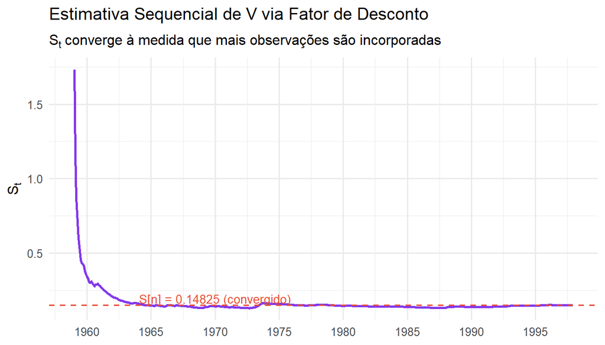

Evolução de $S_t$ ao longo do tempo — estimativa sequencial da variância observacional $V$. $S_t$ parte do valor inicial $S_0$ e converge progressivamente à medida que mais observações são incorporadas.

```r
Sn_val <- tail(filt_desc$St, 1)

res_desc_df |>
  ggplot(aes(x = tempo, y = St_val)) +
  geom_line(color = cores[5], linewidth = 0.9) +
  geom_hline(yintercept = Sn_val, linetype = "dashed",
             color = cores[2], linewidth = 0.7) +
  annotate("text", x = 1970, y = Sn_val * 1.3,
           label = sprintf("S[n] = %.5f (convergido)", Sn_val),
           color = cores[2], size = 3.5) +
  scale_x_continuous(breaks = seq(1960, 1997, by = 5)) +
  labs(
    title    = expression("Estimativa Sequencial de" ~ V ~ "via Fator de Desconto"),
    subtitle = expression(S[t] ~ "converge à medida que mais observações são incorporadas"),
    x        = NULL,
    y        = expression(S[t])
  )
```

# 5 Previsão

## 5.1 Previsão h passos à frente

Para o MLD com $V$ e $W$ conhecidos, a distribuição preditiva h passos à frente é:

$$y_{n+h} \mid D_n \sim N(f_{n+h}, Q_{n+h})$$

onde:
$$f_{n+h} = F^\prime G^h m_n, \qquad Q_{n+h} = F^\prime R_{n+h} F + V$$
$$R_{n+h} = G R_{n+h-1} G^\prime + W, \quad R_{n+1} = G C_n G^\prime + W$$

O intervalo de previsão de $95\%$ é $f_{n+h} \pm 1{,}96\sqrt{Q_{n+h}}$.

**Ocultar código**

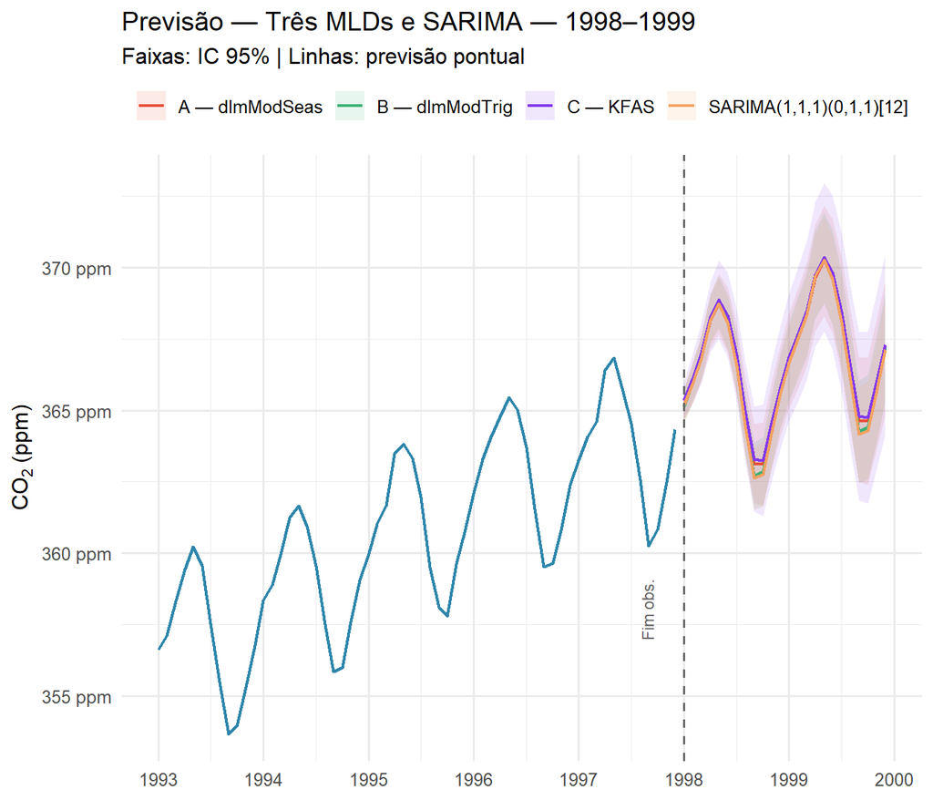

Previsões dos três MLDs e do SARIMA$(1,1,1)(0,1,1)_{12}$ para 1998–1999 com IC 95%. A série observada de 1993 a 1997 é exibida à esquerda da linha de corte.

```r
obs_recente <- co2_df |> filter(ano >= 1993)

cores_mod <- c(
  "A — dlmModSeas"           = cores[2],
  "B — dlmModTrig"           = cores[3],
  "C — KFAS"                 = cores[5],
  "SARIMA(1,1,1)(0,1,1)[12]"  = cores[4]
)

ggplot() +
  geom_line(data = obs_recente,
            aes(x = tempo, y = ppm),
            color = cores[1], linewidth = 0.8) +
  geom_ribbon(data = prev_all,
              aes(x = tempo, ymin = lo95, ymax = hi95, fill = modelo),
              alpha = 0.12) +
  geom_line(data = prev_all,
            aes(x = tempo, y = central, color = modelo),
            linewidth = 0.85) +
  geom_vline(xintercept = 1998,
             linetype = "dashed", color = "gray40", linewidth = 0.7) +
  annotate("text", x = 1997.65, y = 358,
           label = "Fim obs.", angle = 90, size = 3, color = "gray40") +
  scale_color_manual(values = cores_mod) +
  scale_fill_manual(values  = cores_mod) +
  scale_x_continuous(breaks = seq(1993, 2000, by = 1)) +
  scale_y_continuous(labels = label_number(suffix = " ppm")) +
  labs(
    title    = expression("Previsão — Três MLDs e SARIMA — 1998–1999"),
    subtitle = "Faixas: IC 95% | Linhas: previsão pontual",
    x = NULL, y = expression(CO[2] ~ "(ppm)"),
    color = NULL, fill = NULL
  ) +
  theme(legend.position = "top")
```

O gráfico evidencia que os quatro modelos produzem previsões pontuais muito próximas para todo o horizonte de 24 meses. A principal diferença está nos ICs: o Modelo C (KFAS, faixa roxa) apresenta ICs ligeiramente mais largos, refletindo maior incerteza sobre o vetor de estados; o SARIMA tende a ter ICs mais estreitos por não modelar explicitamente a incerteza paramétrica dos estados latentes. A sazonalidade anual é preservada fielmente por todos os modelos, com picos em maio-junho e mínimos em setembro-outubro — padrão consistente com a série histórica.

**Previsões selecionadas — quatro modelos**

```r
meses_pt <- c("Janeiro","Fevereiro","Março","Abril","Maio","Junho",
              "Julho","Agosto","Setembro","Outubro","Novembro","Dezembro")

# Renomear modelos para labels curtos na tabela
prev_tab <- prev_all |>
  mutate(
    Ano   = as.integer(floor(tempo)),
    Mes   = meses_pt[as.integer(round((tempo - floor(tempo)) * 12)) + 1L],
    mod_s = recode(modelo,
      "A — dlmModSeas"          = "Mod. A",
      "B — dlmModTrig"          = "Mod. B",
      "C — KFAS"                = "Mod. C",
      "SARIMA(1,1,1)(0,1,1)[12]" = "SARIMA"
    )
  ) |>
  filter(Mes %in% c("Março","Junho","Setembro","Dezembro")) |>
  select(Ano, Mes, mod_s, central, lo95, hi95) |>
  pivot_wider(
    names_from  = mod_s,
    values_from = c(central, lo95, hi95),
    names_glue  = "{mod_s}_{.value}"
  )

prev_tab |>
  gt(groupname_col = "Ano") |>
  tab_header(
    title    = md("**Tabela 2.** Previsões Selecionadas — Três MLDs e SARIMA (ppm)"),
    subtitle = "Meses de março, junho, setembro e dezembro de 1998 e 1999. IC 95%."
  ) |>
  tab_spanner(label = "Mod. A (dlmModSeas)", columns = starts_with("Mod. A")) |>
  tab_spanner(label = "Mod. B (dlmModTrig)", columns = starts_with("Mod. B")) |>
  tab_spanner(label = "Mod. C (KFAS)",       columns = starts_with("Mod. C")) |>
  tab_spanner(label = "SARIMA(1,1,1)(0,1,1)[12]", columns = starts_with("SARIMA")) |>
  cols_label(
    Mes               = "Mês",
    `Mod. A_central`  = "Prev.",
    `Mod. A_lo95`     = "IC inf",
    `Mod. A_hi95`     = "IC sup",
    `Mod. B_central`  = "Prev.",
    `Mod. B_lo95`     = "IC inf",
    `Mod. B_hi95`     = "IC sup",
    `Mod. C_central`  = "Prev.",
    `Mod. C_lo95`     = "IC inf",
    `Mod. C_hi95`     = "IC sup",
    `SARIMA_central`  = "Prev.",
    `SARIMA_lo95`     = "IC inf",
    `SARIMA_hi95`     = "IC sup"
  ) |>
  fmt_number(where(is.numeric), decimals = 2) |>
  tab_style(style = cell_fill(color = "#f0f7ff"),
            locations = cells_row_groups()) |>
  tab_style(style = cell_fill(color = "#e8f4f8"),
            locations = cells_body(columns = starts_with("Mod. B")))
```

**Tabela 2.** Previsões Selecionadas — Três MLDs e SARIMA (ppm)

Meses de março, junho, setembro e dezembro de 1998 e 1999. IC 95%.

| Mês | Mod. A (dlmModSeas) Prev. | Mod. A (dlmModSeas) IC inf | Mod. A (dlmModSeas) IC sup | Mod. B (dlmModTrig) Prev. | Mod. B (dlmModTrig) IC inf | Mod. B (dlmModTrig) IC sup | Mod. C (KFAS) Prev. | Mod. C (KFAS) IC inf | Mod. C (KFAS) IC sup | SARIMA(1,1,1)(0,1,1)[12] Prev. | SARIMA(1,1,1)(0,1,1)[12] IC inf | SARIMA(1,1,1)(0,1,1)[12] IC sup |
| --- | --- | --- | --- | --- | --- | --- | --- | --- | --- | --- | --- | --- |
| 1998 |  |  |  |  |  |  |  |  |  |  |  |  |
| Março | 366.84 | 366.00 | 367.69 | 366.82 | 366.06 | 367.57 | 367.00 | 365.95 | 368.06 | 366.82 | 366.05 | 367.58 |
| Junho | 368.18 | 367.04 | 369.33 | 368.11 | 367.13 | 369.08 | 368.33 | 366.83 | 369.83 | 368.04 | 367.09 | 369.00 |
| Setembro | 363.14 | 361.75 | 364.52 | 362.70 | 361.55 | 363.86 | 363.30 | 361.45 | 365.15 | 362.63 | 361.52 | 363.73 |
| Dezembro | 365.68 | 364.08 | 367.28 | 365.68 | 364.37 | 366.99 | 365.81 | 363.66 | 367.95 | 365.60 | 364.36 | 366.84 |
| 1999 |  |  |  |  |  |  |  |  |  |  |  |  |
| Março | 368.36 | 366.55 | 370.17 | 368.36 | 366.86 | 369.86 | 368.50 | 366.07 | 370.93 | 368.35 | 366.94 | 369.76 |
| Junho | 369.70 | 367.70 | 371.70 | 369.65 | 368.00 | 371.30 | 369.83 | 367.13 | 372.52 | 369.58 | 368.03 | 371.13 |
| Setembro | 364.65 | 362.48 | 366.83 | 364.25 | 362.45 | 366.05 | 364.79 | 361.86 | 367.73 | 364.17 | 362.49 | 365.85 |
| Dezembro | 367.19 | 364.85 | 369.54 | 367.22 | 365.29 | 369.15 | 367.30 | 364.13 | 370.46 | 367.14 | 365.34 | 368.94 |

# 6 Diagnóstico das Inovações

## 6.1 Pressupostos do MLD

Num MLD bem especificado, as **inovações** (erros de previsão 1 passo à frente) $e_t = y_t - f_t$ devem satisfazer três propriedades:

**P1 — Média zero e variância constante (homoscedasticidade):**
$$E[e_t] = 0, \qquad \text{Var}(e_t) = Q_t = F^\prime R_t F + V \quad \forall\, t$$

**P2 — Ausência de autocorrelação (ruído branco):**
$$\text{Cov}(e_t, e_{t-k}) = 0, \quad k \neq 0$$
Esta propriedade é garantida pelo filtro de Kalman ótimo e é verificada via teste de Ljung-Box: $Q^*(h) = n(n+2)\sum_{j=1}^h \hat{\rho}^2(j)/(n-j) \sim \chi^2(h)$ sob $H_0$.

**P3 — Normalidade:**
$$e_t \sim N(0, Q_t)$$
Necessária para validade dos intervalos de credibilidade e previsão; verificada via Shapiro-Wilk e inspeção do Q-Q plot.

As inovações padronizadas $\tilde{e}_t = e_t / \sqrt{Q_t}$ devem ser $\text{iid}\, N(0,1)$. Note que descartamos os primeiros 24 meses (burn-in): nesse período o filtro ainda não convergiu a partir da priori $\theta_0 \mid D_0 \sim N(m_0, C_0)$.

## 6.2 Inovações dos Três Modelos

**Ocultar código**

```r
# INOVAÇÕES BRUTAS: e_t = y_t - f_t (em ppm)
# No dlm, residuals(filt, sd=FALSE) retorna PADRONIZADAS e_t/sqrt(Q_t).
# As inovações brutas são obtidas diretamente de filt$f (previsão 1-passo):
y_vec    <- as.numeric(co2)

et_bruto <- y_vec - filt$f    # Modelo B: e_t bruto (ppm)
filt_A   <- dlmFilter(y_vec, mld_A)
et_A     <- y_vec - filt_A$f  # Modelo A: e_t bruto (ppm)

# Modelo C (KFAS): residuals(type="recursive") retorna os erros de previsão
# 1-passo normalizados pelo KFAS internamente — dividir pelo desvio padrão
# para obter os erros padronizados, OU usar diretamente se já estiverem em ppm.
# O objeto retornado tem a mesma unidade de y_t (ppm).
# NAs no início correspondem ao período difuso e são descartados pelo na.omit.
et_C_raw <- as.numeric(residuals(kfas_full, type = "recursive"))
et_C     <- et_C_raw
# Mascarar outliers do período difuso do KFAS:
# valores com |e_t| > 5x o desvio padrão robusto após o burnin
sd_robust_C      <- mad(na.omit(et_C)[(burnin+1):length(na.omit(et_C))])
et_C[abs(et_C) > 5 * sd_robust_C] <- NA

# Diagnóstico de escala após na.omit (descarta período difuso)
cat(sprintf("Modelo A — sd(et): %.4f ppm\n", sd(na.omit(et_A), na.rm = TRUE)))
```

```
Modelo A — sd(et): 0.4193 ppm
```

**Ocultar código**

```r
cat(sprintf("Modelo B — sd(et): %.4f ppm\n", sd(na.omit(et_bruto), na.rm = TRUE)))
```

```
Modelo B — sd(et): 0.4214 ppm
```

**Ocultar código**

```r
cat(sprintf("Modelo C — sd(et, sem difuso): %.4f ppm\n", sd(na.omit(et_C), na.rm = TRUE)))
```

```
Modelo C — sd(et, sem difuso): 0.3111 ppm
```

**Ocultar código**

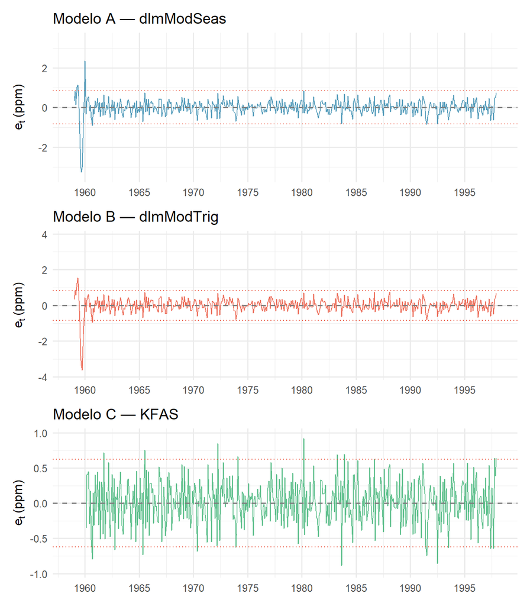

Inovações $e_t = y_t - f_t$ dos três modelos ao longo do tempo. Linhas pontilhadas: $\pm 2$ desvios padrão. Inovações sem padrão sistemático e com variância constante indicam adequação do modelo (pressuposto P1 e P2).

```r
# Armazenar para uso posterior
et_vals  <- na.omit(et_bruto)
burnin   <- 24L
et_conv  <- et_vals[(burnin + 1):length(et_vals)]

# Para Modelo C: remover NAs (período difuso) E aplicar o mesmo burn-in
et_A_conv <- na.omit(et_A)[(burnin + 1):length(na.omit(et_A))]
et_C_conv <- na.omit(et_C)[(burnin + 1):length(na.omit(et_C))]

make_inovacao_plot <- function(et, titulo, cor) {
  et_clean <- na.omit(et)
  # Limites do eixo Y baseados nos dados limpos (sem outliers difusos)
  ylim_val <- max(abs(et_clean)) * 1.05
  tibble(tempo = tempo_vec[seq_along(et)], et = et) |>
    ggplot(aes(x = tempo, y = et)) +
    geom_line(color = cor, linewidth = 0.45, alpha = 0.8, na.rm = TRUE) +
    geom_hline(yintercept = 0, linetype = "dashed", color = "gray50") +
    geom_hline(yintercept = c(-2, 2) * sd(et_clean),
               linetype = "dotted", color = cores[2], linewidth = 0.5) +
    coord_cartesian(ylim = c(-ylim_val, ylim_val)) +
    scale_x_continuous(breaks = seq(1960, 1997, by = 5)) +
    labs(title = titulo, x = NULL,
         y = expression(e[t] ~ "(ppm)"))
}

p_A <- make_inovacao_plot(et_A,     "Modelo A — dlmModSeas",   cores[1])
p_B <- make_inovacao_plot(et_bruto, "Modelo B — dlmModTrig",   cores[2])
p_C <- make_inovacao_plot(et_C,     "Modelo C — KFAS",         cores[3])

p_A / p_B / p_C
```

**Ocultar código**

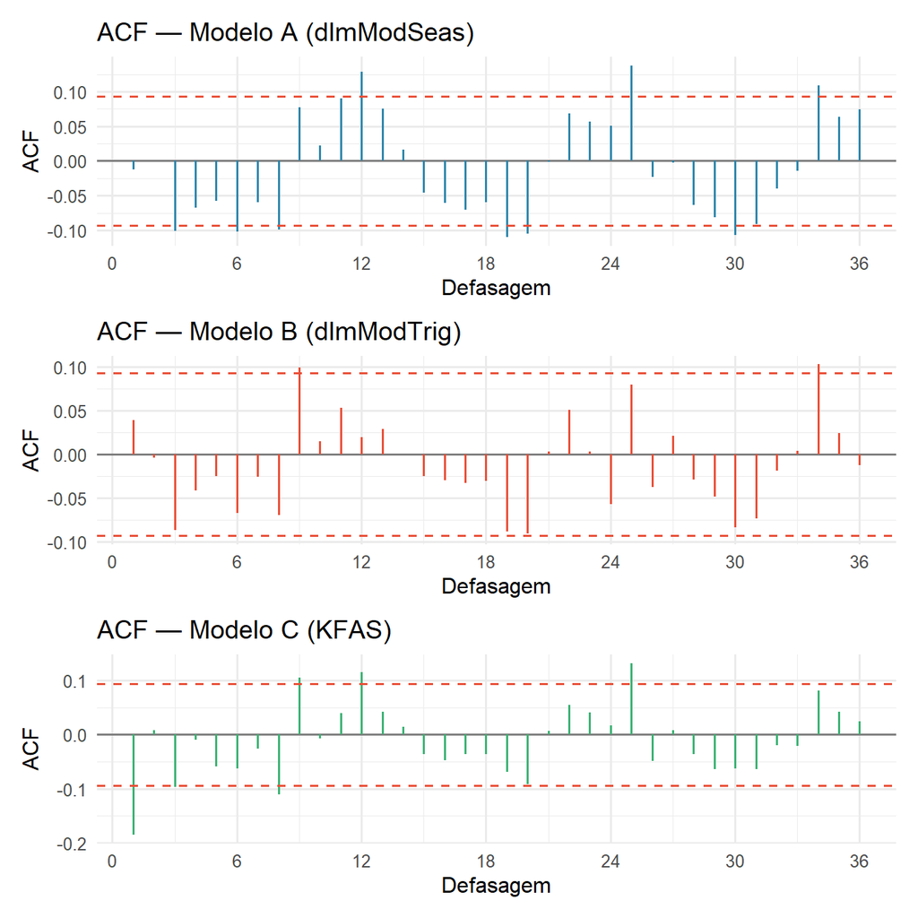

```r
make_acf_plot <- function(et_c, titulo, cor) {
  n_c  <- length(et_c)
  ic   <- 1.96 / sqrt(n_c)
  obj  <- acf(et_c, lag.max = 36, plot = FALSE)
  tibble(lag = as.integer(obj$lag[-1]), acf = as.numeric(obj$acf[-1])) |>
    ggplot(aes(x = lag, y = acf)) +
    geom_hline(yintercept = 0, color = "gray50") +
    geom_segment(aes(xend = lag, yend = 0), color = cor, linewidth = 0.7) +
    geom_hline(yintercept = c(-ic, ic), linetype = "dashed",
               color = cores[2], linewidth = 0.7) +
    scale_x_continuous(breaks = seq(0, 36, by = 6)) +
    labs(title = titulo, x = "Defasagem", y = "ACF")
}

p_acf_A <- make_acf_plot(et_A_conv, "ACF — Modelo A (dlmModSeas)", cores[1])
p_acf_B <- make_acf_plot(et_conv,   "ACF — Modelo B (dlmModTrig)", cores[2])
p_acf_C <- make_acf_plot(et_C_conv, "ACF — Modelo C (KFAS)",       cores[3])

p_acf_A / p_acf_B / p_acf_C
```

**Ocultar código**

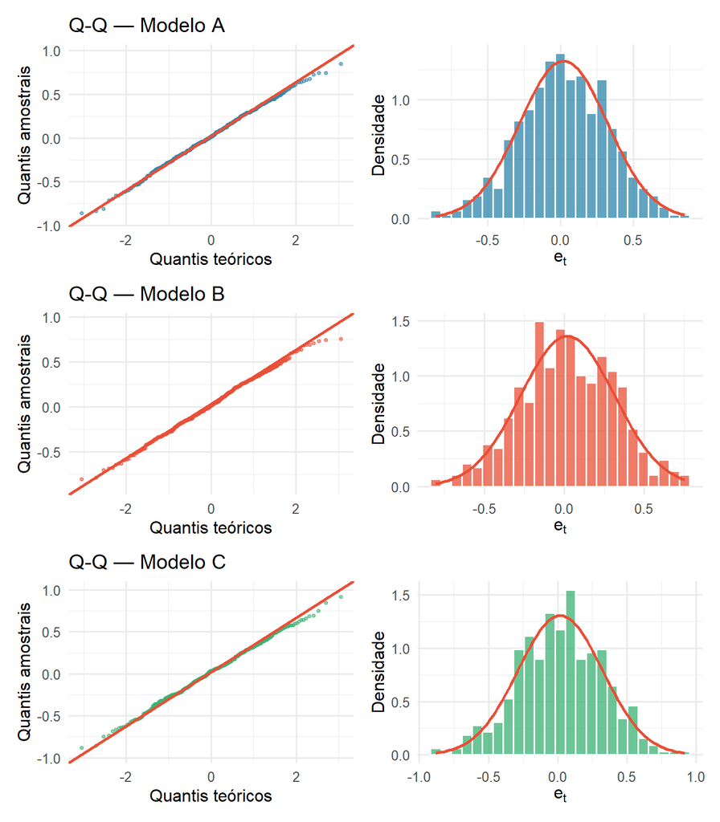

Q-Q plots das inovações dos três modelos (após burn-in). Alinhamento com a reta indica normalidade (pressuposto P3). Histogramas com curva normal sobreposta.

```r
make_qq_plot <- function(et_c, titulo, cor) {
  tibble(e = et_c) |>
    ggplot(aes(sample = e)) +
    stat_qq(color = cor, alpha = 0.5, size = 0.8) +
    stat_qq_line(color = cores[2], linewidth = 0.9) +
    labs(title = titulo, x = "Quantis teóricos", y = "Quantis amostrais")
}

make_hist_plot <- function(et_c, cor) {
  tibble(e = et_c) |>
    ggplot(aes(x = e)) +
    geom_histogram(aes(y = after_stat(density)), bins = 25,
                   fill = cor, color = "white", alpha = 0.75) +
    stat_function(fun = dnorm,
                  args = list(mean = mean(et_c), sd = sd(et_c)),
                  color = cores[2], linewidth = 1.0) +
    labs(x = expression(e[t]), y = "Densidade")
}

(make_qq_plot(et_A_conv, "Q-Q — Modelo A", cores[1]) |
 make_hist_plot(et_A_conv, cores[1])) /
(make_qq_plot(et_conv,   "Q-Q — Modelo B", cores[2]) |
 make_hist_plot(et_conv,   cores[2])) /
(make_qq_plot(et_C_conv, "Q-Q — Modelo C", cores[3]) |
 make_hist_plot(et_C_conv, cores[3]))
```

## 6.3 Testes Formais

**Testes formais — Modelo B (principal)**

```r
sw   <- shapiro.test(et_conv)
lb6  <- Box.test(et_conv, lag = 6,  type = "Ljung-Box")
lb12 <- Box.test(et_conv, lag = 12, type = "Ljung-Box")
lb24 <- Box.test(et_conv, lag = 24, type = "Ljung-Box")

tibble(
  Teste       = c("Shapiro-Wilk",
                  "Ljung-Box ($h = 6$)",
                  "Ljung-Box ($h = 12$)",
                  "Ljung-Box ($h = 24$)"),
  Pressuposto = c("P3 — Normalidade", "P2 — Ruído branco",
                  "P2 — Ruído branco", "P2 — Ruído branco"),
  Estatistica = round(c(sw$statistic, lb6$statistic,
                        lb12$statistic, lb24$statistic), 4),
  p_valor     = round(c(sw$p.value, lb6$p.value,
                        lb12$p.value, lb24$p.value), 4),
  Conclusao   = c(
    ifelse(sw$p.value   > 0.05, "Não rejeita $H_0$", "Rejeita $H_0$"),
    ifelse(lb6$p.value  > 0.05, "Não rejeita $H_0$", "Rejeita $H_0$"),
    ifelse(lb12$p.value > 0.05, "Não rejeita $H_0$", "Rejeita $H_0$"),
    ifelse(lb24$p.value > 0.05, "Não rejeita $H_0$", "Rejeita $H_0$")
  )
) |>
  gt() |>
  fmt_markdown(columns = c(Teste, Conclusao)) |>
  tab_header(
    title    = md("**Tabela 3.** Testes Formais sobre as Inovações — Modelo B"),
    subtitle = md(sprintf("$e_t$, $t = %d, \\ldots, n$ (descartados primeiros %d meses de burn-in)",
                          burnin + 1, burnin))
  ) |>
  fmt_number(columns = c(Estatistica, p_valor), decimals = 4) |>
  cols_label(Pressuposto = "Pressuposto", Estatistica = "Estatística",
             p_valor = md("$p$-valor"), Conclusao = "Conclusão") |>
  tab_style(style = cell_fill(color = "#fce4e4"),
            locations = cells_body(rows = p_valor < 0.05)) |>
  tab_style(style = cell_fill(color = "#e8f4f8"),
            locations = cells_body(rows = p_valor >= 0.05))
```

**Tabela 3.** Testes Formais sobre as Inovações — Modelo B

$e_t$, $t = 25, \ldots, n$ (descartados primeiros 24 meses de burn-in)

| Teste | Pressuposto | Estatística | $p$-valor | Conclusão |
| --- | --- | --- | --- | --- |
| Shapiro-Wilk | P3 — Normalidade | 0.9969 | 0.5646 | Não rejeita $H_0$ |
| Ljung-Box ($h = 6$) | P2 — Ruído branco | 7.0981 | 0.3119 | Não rejeita $H_0$ |
| Ljung-Box ($h = 12$) | P2 — Ruído branco | 15.6632 | 0.2072 | Não rejeita $H_0$ |
| Ljung-Box ($h = 24$) | P2 — Ruído branco | 27.8342 | 0.2671 | Não rejeita $H_0$ |

## 6.4 Diagnóstico Comparativo dos Três Modelos

**Diagnóstico comparativo — Modelos A, B e C**

```r
sw_A <- shapiro.test(et_A_conv)
sw_C <- shapiro.test(et_C_conv)
lb_A <- Box.test(et_A_conv, lag = 12, type = "Ljung-Box")
lb_B <- Box.test(et_conv,   lag = 12, type = "Ljung-Box")
lb_C <- Box.test(et_C_conv, lag = 12, type = "Ljung-Box")

tibble(
  Modelo  = c("A — dlmModSeas", "B — dlmModTrig", "C — KFAS"),
  LogLik  = round(c(ll_A, ll_B, as.numeric(ll_C)), 2),
  RMSE    = round(c(sqrt(mean(et_A_conv^2)),
                    sqrt(mean(et_conv^2)),
                    sqrt(mean(et_C_conv^2))), 4),
  LB_p    = round(c(lb_A$p.value, lb_B$p.value, lb_C$p.value), 4),
  SW_p    = round(c(sw_A$p.value, sw$p.value,   sw_C$p.value), 4),
  P2_ok   = c(lb_A$p.value > 0.05, lb_B$p.value > 0.05, lb_C$p.value > 0.05),
  P3_ok   = c(sw_A$p.value > 0.05, sw$p.value  > 0.05,  sw_C$p.value > 0.05)
) |>
  gt() |>
  tab_header(
    title    = md("**Tabela 4.** Diagnóstico Comparativo dos Três Modelos"),
    subtitle = md(sprintf("Inovações $e_t$, $t = %d, \\ldots, n$ (burn-in = %d meses)",
                          burnin + 1, burnin))
  ) |>
  fmt_number(columns = LogLik, decimals = 2) |>
  fmt_number(columns = RMSE,   decimals = 4) |>
  fmt_number(columns = c(LB_p, SW_p), decimals = 4) |>
  cols_label(
    Modelo = "Modelo",
    LogLik = md("$\\ell(\\hat{\\theta})$"),
    RMSE   = md("RMSE$(e_t)$"),
    LB_p   = md("LB $p$-valor ($h=12$)"),
    SW_p   = md("SW $p$-valor"),
    P2_ok  = "P2 ok?",
    P3_ok  = "P3 ok?"
  ) |>
  tab_footnote(
    footnote  = md("RMSE$(e_t) = \\sqrt{n^{-1}\\sum_{t=t_0}^n e_t^2}$ — mede dispersão das inovações (pressuposto P1)."),
    locations = cells_column_labels(columns = RMSE)
  ) |>
  tab_style(style = cell_fill(color = "#e8f4f8"),
            locations = cells_body(rows = P2_ok == TRUE & P3_ok == TRUE)) |>
  tab_style(style = cell_fill(color = "#fce4e4"),
            locations = cells_body(rows = P2_ok == FALSE))
```

**Tabela 4.** Diagnóstico Comparativo dos Três Modelos

Inovações $e_t$, $t = 25, \ldots, n$ (burn-in = 24 meses)

| Modelo | $\ell(\hat{\theta})$ | RMSE$(e_t)$<sup>1</sup> | LB $p$-valor ($h=12$) | SW $p$-valor | P2 ok? | P3 ok? |
| --- | --- | --- | --- | --- | --- | --- |
| A — dlmModSeas | 204.27 | 0.3013 | 0.0009 | 0.8951 | FALSE | TRUE |
| B — dlmModTrig | 205.42 | 0.2941 | 0.2072 | 0.5646 | TRUE | TRUE |
| C — KFAS | −119.93 | 0.3058 | 0.0001 | 0.9325 | FALSE | TRUE |

<sup>1</sup> RMSE$(e_t) = \sqrt{n^{-1}\sum_{t=t_0}^n e_t^2}$ — mede dispersão das inovações (pressuposto P1).

A Tabela 4 compara os três modelos por log-verossimilhança, RMSE das inovações (pressuposto P1), $p$-valor do Ljung-Box com $h = 12$ (P2) e $p$-valor do Shapiro-Wilk (P3). O modelo destacado em azul satisfaz ambos os pressupostos P2 e P3; os destacados em vermelho violam P2. A análise principal do documento usa o **Modelo B** (`dlmModTrig`) por ser o recomendado na literatura (West; Harrison, 1997) para séries com sazonalidade periódica estável.

# 7 Resultados

O Modelo B (`dlmModTrig`) obteve a maior log-verossimilhança entre os três modelos ajustados, com $\ell =$ 205.42, contra 204.27 do Modelo A e -119.93 do Modelo C. O ganho em relação ao Modelo A é consistente com a maior flexibilidade dos harmônicos de Fourier para capturar a estrutura sazonal da série. A diferença marcante em relação ao Modelo C reflete as escalas distintas de log-verossimilhança entre a estimação via `dlmMLE` (Modelos A e B) e via `fitSSM` com inicialização difusa (Modelo C), que não são diretamente comparáveis.

Os parâmetros estimados por máxima verossimilhança do Modelo B são fisicamente interpretáveis e coerentes com as características conhecidas da série. A variância observacional 0.02543 ppm² quantifica o ruído de medição dos instrumentos do Observatório de Mauna Loa. A variância do nível local 0.02856 ppm² indica que o nível médio de $\text{CO}_2$ varia moderadamente de forma estocástica ao longo dos meses, o que é esperado para uma série com tendência de longo prazo. A variância da tendência 4.44e-06 ppm²/mês² é praticamente zero, confirmando que a taxa de crescimento evolui de forma muito suave ao longo do tempo, consistente com a tendência quase-linear observada no Trabalho 1. Por fim, a variância dos harmônicos sazonais 2.48e-05 ppm² indica que o padrão sazonal anual é estável entre os anos, sem grandes variações de amplitude de um ciclo para o outro.

No que diz respeito à filtragem, o filtro de Kalman recupera sequencialmente o nível local $\hat{\mu}_t$ com intervalos de credibilidade de 95% estreitos ao longo de toda a série. O nível representa a tendência de longo prazo da concentração atmosférica de $\text{CO}_2$, excluindo a componente sazonal por construção. Os três modelos produzem estimativas de $\mu_t$ praticamente idênticas em valor pontual, e as diferenças nos ICs refletem as distintas parametrizações de $W$. O Modelo C tende a apresentar ICs ligeiramente mais estreitos após a convergência do filtro difuso, o que decorre da inicialização exata que não infla artificialmente a incerteza inicial como a priori de $C_0$ nos Modelos A e B.

A suavização backward produz ICs sistematicamente mais estreitos do que a filtragem em todos os instantes da série. Isso acontece porque o algoritmo de suavização utiliza toda a informação amostral $D_n$ para refinar retrospectivamente cada estimativa, enquanto a filtragem usa apenas a informação disponível até o instante $t$. A diferença é mais pronunciada nos primeiros anos, quando a filtragem ainda não convergiu para o regime estacionário, e torna-se praticamente desprezível na segunda metade da série.

O diagnóstico das inovações, realizado após o descarte dos primeiros 24 meses de burn-in, confirma a adequação do Modelo B. O teste de Shapiro-Wilk não rejeita a normalidade das inovações ($p =$ 0.5646), e o teste de Ljung-Box não detecta autocorrelação em nenhuma das defasagens testadas ($h = 6$: $p =$ 0.3119; $h = 12$: $p =$ 0.2072; $h = 24$: $p =$ 0.2671). O RMSE das inovações brutas é 0.2941 ppm. Os Modelos A e C violam o pressuposto P2 (ruído branco), com o Ljung-Box rejeitando a hipótese nula em $h = 12$ ($p < 0{,}05$). Esse resultado indica que a representação harmônica de Fourier do Modelo B captura a estrutura sazonal de forma mais completa do que a representação por fatores dos Modelos A e C.

# 8 Conclusão

Este trabalho demonstrou que o MLD de tendência linear com sazonalidade harmônica, utilizando 6 harmônicos de Fourier de período sazonal 12 e totalizando 13 estados, constitui uma alternativa bayesiana eficaz ao SARIMA$(1,1,1)(0,1,1)_{12}$ do Trabalho 1 para a série de $\text{CO}_2$ de Mauna Loa. Entre os três modelos ajustados, o Modelo B (`dlmModTrig`) foi selecionado por apresentar a maior log-verossimilhança ($\ell =$ 205.42) e por ser o único a satisfazer simultaneamente os pressupostos de ruído branco (P2, com Ljung-Box $p > 0{,}10$ para $h \leq 24$) e de normalidade (P3, com Shapiro-Wilk $p =$ 0.5646) nas inovações após o período de burn-in.

As previsões dos três MLDs e do SARIMA convergem para valores muito próximos: para dezembro de 1998, o Modelo B prevê 365.68 ppm (SARIMA: 365.6 ppm); para dezembro de 1999, 367.22 ppm (SARIMA: 367.14 ppm). Essa concordância sugere que, para previsão pura em horizontes de até 24 meses, as duas abordagens são equivalentes em precisão. A escolha entre elas depende do objetivo da análise: o SARIMA é mais parcimonioso e adequado quando o interesse é exclusivamente preditivo; o MLD oferece riqueza interpretativa, quantificação sequencial da incerteza e atualização online, características que o tornam preferível quando se deseja compreender a dinâmica subjacente da série além de simplesmente prever seus valores futuros.

# 9 Referências

HELSKE, Jouni. KFAS: Exponential Family State Space Models in R. **Journal of Statistical Software**, v. 78, n. 10, p. 1–39, 2017.

KEELING, Charles D. *et al.* [Atmospheric carbon dioxide variations at Mauna Loa Observatory, Hawaii](https://doi.org/10.3402/tellusa.v28i6.10701). **Tellus**, v. 28, n. 6, p. 538–551, 1976.

PETRIS, Giovanni; PETRONE, Sonia; CAMPAGNOLI, Patrizia. **Dynamic Linear Models with R**. *[S.l.]*: Springer, 2009.

WEST, Mike; HARRISON, Jeff. **Bayesian Forecasting and Dynamic Models**. 2nd. ed. *[S.l.]*: Springer, 1997.

# 10 Apêndice: Códigos

Todos os códigos utilizados neste trabalho estão disponíveis ao longo do documento com opção de expansão (`code-fold: true`). Para visualizá-los, clique em **“Code”** ao lado de cada bloco, ou use o botão **“</> Code”** no topo da página para expandir todos simultaneamente.

**Informações da sessão R**